# ACCEL — Leadership talent at recent unicorns

This document summarizes **who leads today's breakout technology companies**—where they studied, the employers that shaped them, how geographically mobile teams are, and how much operating history leaders carry into the unicorn chapter. The emphasis is on **patterns that inform judgment**: concentrations versus long tails, how 2023+ executive benches differ from earlier co-founder cohorts, and how **US and European talent markets stay linked** through people (closing chart).

The analysis contrasts **three cohorts**—unicorns through 2022 viewed through co-founders, **2023+ senior executives (levels 5–7)**, and **2023+ name-matched co-founders**—so scaled-leadership dynamics can be read separately from classic founder signatures. Employer labels use **company name with country** when available; founding-country counts reflect **distinct individuals** (each person counted once, not once per company).

## ACCEL — Schools, prior employers, tenure, and founding geography

These sections compare the same human themes—education, where people worked before, how long they stayed in roles, and the geography of company formation—across three complementary slices:

1. **Unicorns through 2022 (co-founder lens)** — The classic founder footprint: feeder schools and employers tied to each company's founding location.
2. **2023+ senior leadership (levels 5–7)** — The operating bench around today's breakouts. Prior employers and tenure deliberately **exclude time at the unicorn itself**, so the signal is experience brought **from** the broader market.
3. **2023+ list-matched co-founders** — Founders aligned to external lists when names match—the tightest read on founder education and early employers.

**What to take away:** where leadership talent clusters at schools and companies; how founding-country mixes differ; how deep prior operating histories run (with country-level tenure views where coverage supports it); and how degree level and field-of-study mix compare **among leaders with usable degree information**.

The tables zoom into **largest founding markets**—schools and feeder employers that matter within those geographies.

```
Loading ≤2022 co-founder cohort…
```

Unicorn year ≤2022 — co-founders (tenure uses matched only)  
Top schools, prior employers, people by founding country, and prior tenure

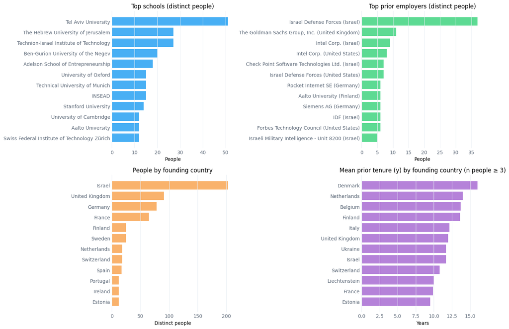

|  | cohort | mean_prior_years | median_prior_years | n_people |
| --- | --- | --- | --- | --- |
| 0 | Unicorn year ≤2022 — co-founders (tenure uses ... | 10.864099 | 9.819302 | 616 |

```
Loading 2023+ executive cohort…
```

2023+ — executive team (seniority 5–7)  
Top schools, prior employers, people by founding country, and prior tenure

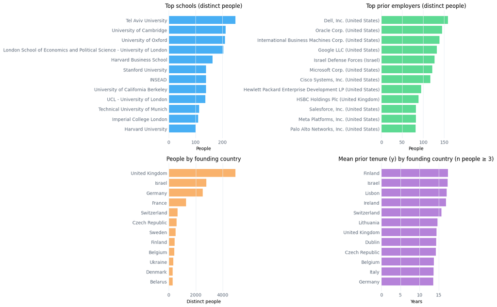

|  | cohort | mean_prior_years | median_prior_years | n_people |
| --- | --- | --- | --- | --- |
| 0 | 2023+ — executive team (seniority 5–7) | 14.428193 | 13.166324 | 16202 |

```
Loading 2023+ matched co-founder cohort…
```

2023+ — matched CSV co-founders only  
Top schools, prior employers, people by founding country, and prior tenure

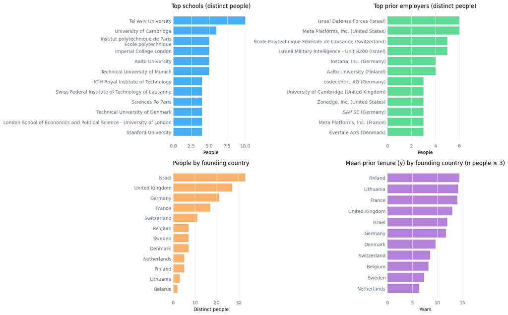

|  | cohort | mean_prior_years | median_prior_years | n_people |
| --- | --- | --- | --- | --- |
| 0 | 2023+ — matched CSV co-founders only | 11.237087 | 9.852156 | 156 |

```
Top schools by founding country — ≤2022 co-founders
```

|  | FOUNDING_COUNTRY | school | n_people |
| --- | --- | --- | --- |
| 0 | Israel | Tel Aviv University | 50 |
| 1 | Israel | Technion-Israel Institute of Technology | 27 |
| 2 | Israel | The Hebrew University of Jerusalem | 27 |
| 3 | Israel | Ben-Gurion University of the Negev | 20 |
| 4 | Israel | Adelson School of Entrepreneurship | 17 |
| 5 | United Kingdom | University of Oxford | 13 |
| 6 | United Kingdom | University of Cambridge | 10 |
| 7 | United Kingdom | The University of Edinburgh | 5 |
| 8 | United Kingdom | University of Leeds | 5 |
| 9 | United Kingdom | London School of Economics and Political Scien... | 4 |
| 10 | Germany | Technical University of Munich | 14 |
| 11 | Germany | WHU - Otto Beisheim School of Management | 10 |
| 12 | Germany | Center for Digital Technology and Management (... | 8 |
| 13 | Germany | Ludwig Maximilian University of Munich | 6 |
| 14 | Germany | University of California Berkeley | 3 |
| 15 | France | Institut polytechnique de Paris\nEcole polytec... | 10 |
| 16 | France | HEC Paris | 6 |
| 17 | France | Sorbonne University | 4 |
| 18 | France | PSL University\nMines ParisTech | 4 |
| 19 | France | Lycée Privé Sainte-Geneviève | 4 |
| 20 | Sweden | KTH Royal Institute of Technology | 6 |
| 21 | Sweden | Stockholm School of Economics | 4 |
| 22 | Sweden | Stockholm University | 3 |
| 23 | Sweden | Harvard University | 2 |
| 24 | Sweden | Lund University | 2 |
| 25 | Finland | Aalto University | 12 |
| 26 | Finland | University of Oulu | 3 |
| 27 | Finland | Berlin School of Creative Leadership | 1 |
| 28 | Finland | Helsingin Suomalainen Yhteiskoulu | 1 |
| 29 | Finland | Lapland University of Applied Sciences | 1 |
| 30 | Switzerland | Swiss Federal Institute of Technology Zürich | 10 |
| 31 | Switzerland | Swiss Federal Institute of Technology of Lausanne | 3 |
| 32 | Switzerland | Woodberry Forest School | 2 |
| 33 | Switzerland | Massachusetts Institute of Technology | 2 |
| 34 | Switzerland | University of Zurich | 2 |
| 35 | Netherlands | University of Amsterdam | 3 |
| 36 | Netherlands | Delft University of Technology | 2 |
| 37 | Netherlands | Transport and Telecommunication Institute | 2 |
| 38 | Netherlands | University of Groningen | 2 |
| 39 | Netherlands | Stanford Graduate School of Business | 2 |

```
Top schools by founding country — 2023+ executives
```

|  | FOUNDING_COUNTRY | school | n_people |
| --- | --- | --- | --- |
| 0 | United Kingdom | University of Cambridge | 131 |
| 1 | United Kingdom | University of Oxford | 122 |
| 2 | United Kingdom | UCL - University of London | 88 |
| 3 | United Kingdom | London School of Economics and Political Scien... | 77 |
| 4 | United Kingdom | Imperial College London | 65 |
| 5 | Israel | Tel Aviv University | 228 |
| 6 | Israel | The Hebrew University of Jerusalem | 89 |
| 7 | Israel | Technion-Israel Institute of Technology | 84 |
| 8 | Israel | Bar-Ilan University | 81 |
| 9 | Israel | Ben-Gurion University of the Negev | 78 |
| 10 | Germany | Technical University of Munich | 84 |
| 11 | Germany | Ludwig Maximilian University of Munich | 47 |
| 12 | Germany | University of Cologne | 35 |
| 13 | Germany | Westphalian Wilhelms University Münster | 34 |
| 14 | Germany | University of Oxford | 31 |
| 15 | France | HEC Paris | 47 |
| 16 | France | Institut polytechnique de Paris\nEcole polytec... | 37 |
| 17 | France | Sciences Po Paris | 36 |
| 18 | France | ESCP Business School | 33 |
| 19 | France | Paris 1 Panthéon-Sorbonne University | 29 |
| 20 | Switzerland | University of St. Gallen | 45 |
| 21 | Switzerland | University of Zurich | 30 |
| 22 | Switzerland | Swiss Federal Institute of Technology Zürich | 22 |
| 23 | Switzerland | University of California Berkeley | 16 |
| 24 | Switzerland | London School of Economics and Political Scien... | 15 |
| 25 | Czech Republic | Prague University of Economics and Business | 17 |
| 26 | Czech Republic | Charles University | 17 |
| 27 | Czech Republic | Cornell University | 12 |
| 28 | Czech Republic | Hotel School The Hague | 10 |
| 29 | Czech Republic | London School of Economics and Political Scien... | 8 |
| 30 | Sweden | KTH Royal Institute of Technology | 27 |
| 31 | Sweden | Stockholm University | 25 |
| 32 | Sweden | Stockholm School of Economics | 24 |
| 33 | Sweden | Harvard Business School | 16 |
| 34 | Sweden | London School of Economics and Political Scien... | 15 |
| 35 | Finland | Aalto University | 53 |
| 36 | Finland | University of Helsinki | 23 |
| 37 | Finland | Harvard Business School | 14 |
| 38 | Finland | Aalto University Executive Education Oy | 14 |
| 39 | Finland | Haaga-Helia University of Applied Sciences | 10 |

```
Top schools by founding country — 2023+ matched co-founders
```

|  | FOUNDING_COUNTRY | school | n_people |
| --- | --- | --- | --- |
| 0 | Israel | Tel Aviv University | 10 |
| 1 | Israel | The Hebrew University of Jerusalem | 3 |
| 2 | Israel | College of Management Academic Studies | 3 |
| 3 | Israel | Adelson School of Entrepreneurship | 2 |
| 4 | Israel | Open University of Israel | 2 |
| 5 | United Kingdom | University of Cambridge | 4 |
| 6 | United Kingdom | Imperial College London | 2 |
| 7 | United Kingdom | Stanford University | 2 |
| 8 | United Kingdom | University of Turin | 2 |
| 9 | United Kingdom | Cambridge Judge Business School | 1 |
| 10 | Germany | Technical University of Munich | 4 |
| 11 | Germany | Center for Digital Technology and Management (... | 2 |
| 12 | Germany | Westphalian Wilhelms University Münster | 2 |
| 13 | Germany | University of California Berkeley | 2 |
| 14 | Germany | University of St. Gallen | 2 |
| 15 | France | Institut polytechnique de Paris\nEcole polytec... | 5 |
| 16 | France | PSL University\nMines ParisTech | 3 |
| 17 | France | Sciences Po Paris | 3 |
| 18 | France | Sorbonne University | 3 |
| 19 | France | École normale supérieure Paris-Saclay | 2 |
| 20 | Switzerland | Swiss Federal Institute of Technology of Lausanne | 4 |
| 21 | Switzerland | London School of Economics and Political Scien... | 3 |
| 22 | Switzerland | University of St. Gallen | 2 |
| 23 | Switzerland | Swiss Federal Institute of Technology Zürich | 2 |
| 24 | Switzerland | Massachusetts Institute of Technology | 1 |
| 25 | Denmark | Technical University of Denmark | 4 |
| 26 | Denmark | University of Padua | 3 |
| 27 | Denmark | Copenhagen Business School | 2 |
| 28 | Denmark | IT University of Copenhagen | 1 |
| 29 | Denmark | University of Turin | 1 |
| 30 | Belgium | Ghent University | 3 |
| 31 | Belgium | Collège Sainte-Marie | 2 |
| 32 | Belgium | Belgium Jobs | 2 |
| 33 | Belgium | Arteveldehogeschool | 1 |
| 34 | Belgium | Faculté Polytechnique de Mons | 1 |
| 35 | Finland | Aalto University | 5 |
| 36 | Finland | Chung Ling (National Type) High School 鍾靈(國民型)中學 | 1 |
| 37 | Finland | Metropolia University of Applied Sciences | 1 |
| 38 | Finland | Technical University of Munich | 1 |
| 39 | Finland | Tunku Abdul Rahman University of Management an... | 1 |

```
Top prior employers by founding country — ≤2022 co-founders
```

|  | FOUNDING_COUNTRY | employer | n_people |
| --- | --- | --- | --- |
| 0 | Israel | Israel Defense Forces | 44 |
| 1 | Israel | Intel Corp. | 17 |
| 2 | Israel | Check Point Software Technologies Ltd. | 8 |
| 3 | Israel | Cyberstarts Venture Fund Ltd. | 8 |
| 4 | Israel | Forbes Technology Council | 7 |
| 5 | United Kingdom | The Goldman Sachs Group, Inc. | 6 |
| 6 | United Kingdom | McKinsey & Co., Inc. | 6 |
| 7 | United Kingdom | Starling Bank Ltd. | 4 |
| 8 | United Kingdom | PricewaterhouseCoopers LLP | 4 |
| 9 | United Kingdom | Yoti Holding Ltd. | 4 |
| 10 | Germany | Rocket Internet SE | 8 |
| 11 | Germany | Siemens AG | 6 |
| 12 | Germany | The Goldman Sachs Group, Inc. | 5 |
| 13 | Germany | Founders For Good Ltd. | 4 |
| 14 | Germany | Personio Foundation | 4 |
| 15 | France | Dassault Systèmes SE | 4 |
| 16 | France | The Goldman Sachs Group, Inc. | 3 |
| 17 | France | eFounders SA | 3 |
| 18 | France | Stratumn SAS | 3 |
| 19 | France | Alstef Mobile Robotics | 2 |
| 20 | Finland | Aalto University | 6 |
| 21 | Finland | Digital Chocolate, Inc. | 5 |
| 22 | Finland | F-Secure Oyj | 4 |
| 23 | Finland | Nokia Oyj | 4 |
| 24 | Finland | Slush Oy | 4 |
| 25 | Sweden | Sweet Capital Ltd. | 4 |
| 26 | Sweden | Fjord Network Ltd. | 3 |
| 27 | Sweden | Razorfish, Inc. /Old/ | 3 |
| 28 | Sweden | Anticimex AB | 2 |
| 29 | Sweden | Försvarsmakten | 2 |
| 30 | Netherlands | Fredhopper BV | 2 |
| 31 | Netherlands | Jteam | 2 |
| 32 | Netherlands | People For People Foundation | 2 |
| 33 | Netherlands | Zaypay International BV | 2 |
| 34 | Netherlands | Sia Zz Dats | 2 |
| 35 | Switzerland | Swiss Federal Institute of Technology | 3 |
| 36 | Switzerland | UBS AG | 2 |
| 37 | Switzerland | École Polytechnique Fédérale de Lausanne | 2 |
| 38 | Switzerland | 21Shares AG | 1 |
| 39 | Switzerland | Arcom AG | 1 |

```
Top prior employers by founding country — 2023+ executives
```

|  | FOUNDING_COUNTRY | employer | n_people |
| --- | --- | --- | --- |
| 0 | United Kingdom | Deloitte LLP (New York) | 101 |
| 1 | United Kingdom | Google LLC | 100 |
| 2 | United Kingdom | International Business Machines Corp. | 99 |
| 3 | United Kingdom | HSBC Holdings Plc | 94 |
| 4 | United Kingdom | Ernst & Young Global Ltd. | 92 |
| 5 | Israel | Dell, Inc. | 178 |
| 6 | Israel | Israel Defense Forces | 137 |
| 7 | Israel | International Business Machines Corp. | 128 |
| 8 | Israel | Hewlett Packard Enterprise Development LP | 101 |
| 9 | Israel | Microsoft Corp. | 97 |
| 10 | Germany | SAP SE | 105 |
| 11 | Germany | McKinsey & Co., Inc. | 52 |
| 12 | Germany | Google LLC | 49 |
| 13 | Germany | Microsoft Corp. | 49 |
| 14 | Germany | International Business Machines Corp. | 45 |
| 15 | France | Anaplan, Inc. | 39 |
| 16 | France | Google LLC | 38 |
| 17 | France | Microsoft Corp. | 38 |
| 18 | France | Deloitte LLP (New York) | 31 |
| 19 | France | International Business Machines Corp. | 30 |
| 20 | Switzerland | Credit Suisse AG | 47 |
| 21 | Switzerland | UBS AG | 44 |
| 22 | Switzerland | Accenture Plc | 27 |
| 23 | Switzerland | International Business Machines Corp. | 21 |
| 24 | Switzerland | Deloitte LLP (New York) | 19 |
| 25 | Czech Republic | Marriott International, Inc. | 20 |
| 26 | Czech Republic | Expedia Group, Inc. | 17 |
| 27 | Czech Republic | Hilton Worldwide Holdings, Inc. | 15 |
| 28 | Czech Republic | Oracle Corp. | 14 |
| 29 | Czech Republic | Sabre Corp. | 11 |
| 30 | Sweden | McKinsey & Co., Inc. | 33 |
| 31 | Sweden | The Boston Consulting Group, Inc. | 28 |
| 32 | Sweden | Spotify Technology SA | 26 |
| 33 | Sweden | Klarna Bank AB | 23 |
| 34 | Sweden | Google LLC | 20 |
| 35 | Finland | Nokia Oyj | 38 |
| 36 | Finland | Aalto University | 25 |
| 37 | Finland | Microsoft Corp. | 18 |
| 38 | Finland | Ernst & Young Global Ltd. | 11 |
| 39 | Finland | European Space Agency (France) | 10 |

```
Top prior employers by founding country — 2023+ matched co-founders
```

|  | FOUNDING_COUNTRY | employer | n_people |
| --- | --- | --- | --- |
| 0 | Israel | Israel Defense Forces | 9 |
| 1 | Israel | Israeli Military Intelligence - Unit 8200 | 8 |
| 2 | Israel | Amazon Web Services, Inc. | 3 |
| 3 | Israel | Center of Computing & Information Systems | 3 |
| 4 | Israel | Luminate Security Ltd. | 3 |
| 5 | United Kingdom | BNP Paribas SA | 2 |
| 6 | United Kingdom | Bvnk Technology UK Ltd. | 2 |
| 7 | United Kingdom | Coincall | 2 |
| 8 | United Kingdom | Founders A/S | 2 |
| 9 | United Kingdom | Oliver Wyman, Inc. | 2 |
| 10 | Germany | Instana, Inc. | 5 |
| 11 | Germany | codecentric AG | 3 |
| 12 | Germany | SAP SE | 3 |
| 13 | Germany | Deutsche Bundeswehr | 2 |
| 14 | Germany | Tesla, Inc. | 2 |
| 15 | France | Meta Platforms, Inc. | 6 |
| 16 | France | DeepMind Technologies Ltd. | 2 |
| 17 | France | Google LLC | 2 |
| 18 | France | New York University | 2 |
| 19 | France | McGill University | 2 |
| 20 | Switzerland | École Polytechnique Fédérale de Lausanne | 5 |
| 21 | Switzerland | Accenture Plc | 2 |
| 22 | Switzerland | International Business Machines Corp. | 2 |
| 23 | Switzerland | Oracle Corp. | 2 |
| 24 | Switzerland | Swiss Federal Institute of Technology | 2 |
| 25 | Belgium | Officient BV | 2 |
| 26 | Belgium | Anheuser-Busch InBev NV | 1 |
| 27 | Belgium | Athora Belgium SA | 1 |
| 28 | Belgium | BBDO | 1 |
| 29 | Belgium | Belgian Maintenance Association | 1 |
| 30 | Sweden | Depictai AB | 3 |
| 31 | Sweden | Abios Gaming AB | 1 |
| 32 | Sweden | Ampfield AB | 1 |
| 33 | Sweden | Astrid Education AB | 1 |
| 34 | Sweden | ABB Ltd. | 1 |
| 35 | Denmark | Evertale ApS | 4 |
| 36 | Denmark | DTU Fotonik | 2 |
| 37 | Denmark | Verisure SARL | 2 |
| 38 | Denmark | Telmore A/S | 2 |
| 39 | Denmark | Mofibo Books ApS | 2 |

≤2022 co-founders — Degree level mix  
Among people with degree level on file; overall and by founding country

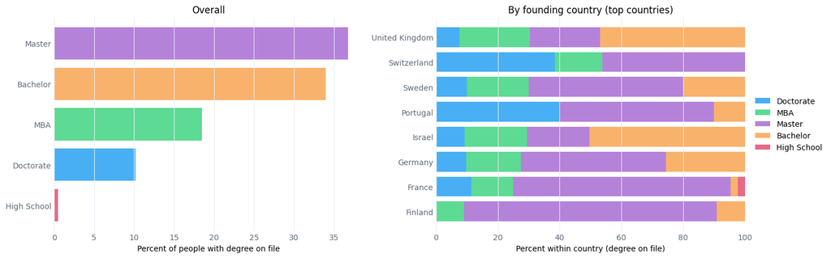

≤2022 co-founders — Degree field / major mix  
Non-empty fields only; overall and by founding country

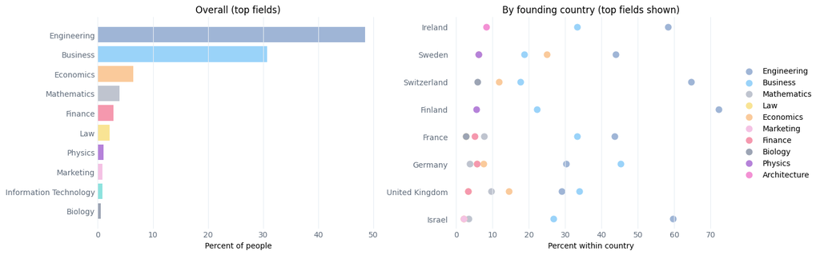

2023+ executives — Degree level mix  
Among people with degree level on file; overall and by founding country

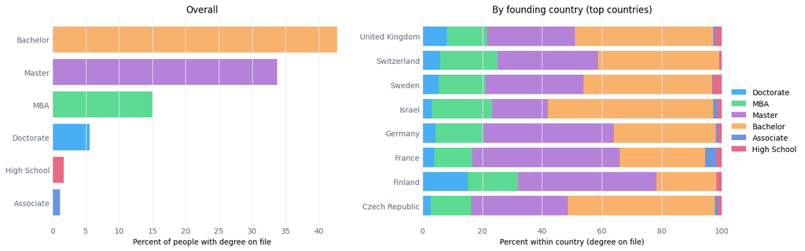

2023+ executives — Degree field / major mix  
Non-empty fields only; overall and by founding country

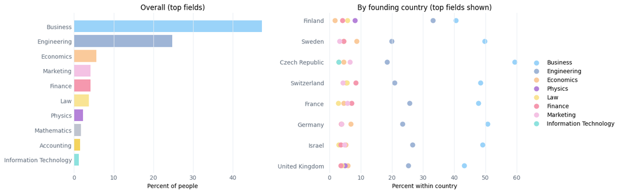

2023+ matched co-founders — Degree level mix  
Among people with degree level on file; overall and by founding country

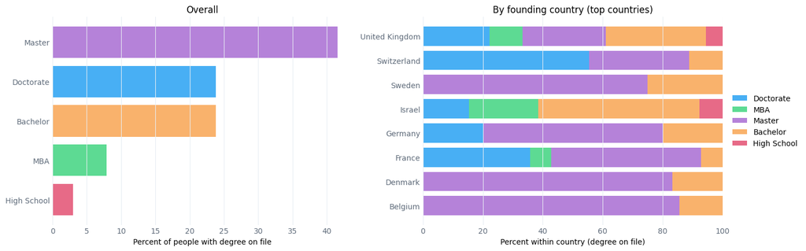

2023+ matched co-founders — Degree field / major mix  
Non-empty fields only; overall and by founding country

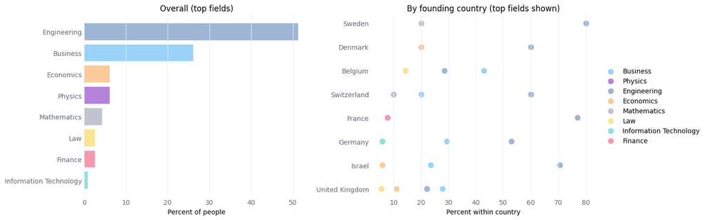

## The US–Europe bridge in tech talent

This closing view tracks **movement of tech talent between the United States and Europe**—often an early signal for cross-border deal flow, platform choices, and where future breakout companies may anchor. Read it together with the leadership profiles above to connect **who is in the room** with **how the two ecosystems stay coupled through people**.

[interactive chart not shown]